# A1_Choi_Ellie

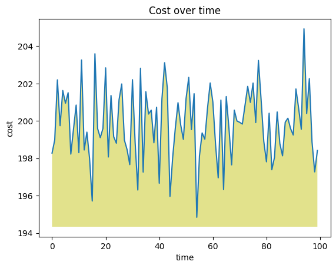

```python
# TASK II : Changing existing code blocks

import matplotlib.pyplot as plt
import numpy as np

#range of data
x=np.arange(100)
y=np.random.normal(200,2,100)

#Create plots
fig, ax=plt.subplots()
ax.plot(x,y)

#Color,Transparency edit, alpha value
ymin=ax.get_ylim()[0]
ax.fill_between(x, y, ymin, facecolor='y', alpha=.45)

#Title, label
plt.title("Cost over time")
plt.xlabel("time")
plt.ylabel("cost")

#display.display(fig)여
plt.show()
```

I modified the graph in the following ways:

- I changed the background color of the area under the line to **yellow** using `facecolor='y'`.
- I set the transparency using `alpha=0.45`, which controls how see-through the background color appears. Lower alpha means more transparent, and higher alpha makes it more solid.
- I updated the graph title to **"Cost over time"**.
- I added axis labels: **"time"** for the x-axis and **"cost"** for the y-axis to make the graph easier to interpret.

Axis labels are important because they show what each part of the graph represents. The alpha parameter is useful for visual clarity — it helps you balance visibility when overlaying elements. When I tried changing the alpha value, the yellow area became lighter or darker depending on the number.

```python
#TASK III : Deleting and adding text blocks
days_in_a_year = 365
seconds_in_a_day = 24 * 60 * 60
seconds_in_a_year = seconds_in_a_day * days_in_a_year
print("Seconds in a year:", seconds_in_a_year)
```

```
Seconds in a year: 31536000
```

```python
# TASK IV : Importing files
import pandas as pd
url="https://raw.githubusercontent.com/matthewpecsok/4482_fall_2024/main/data/assignment_1.csv"
df=pd.read_csv(url)
df.tail(8)
```

|  | customer_id | sale_amount | category |
| --- | --- | --- | --- |
| 0 | 4.0 | 5345.23 | A |
| 1 | 3.0 | 534.65 | B |
| 2 | 5.0 | 456.87 | A |
| 3 | 6.0 | 987.99 | NaN |
| 4 | NaN | 53.14 | A |
| 5 | 1.0 | 2325.23 | NaN |
| 6 | 9.0 | 7657.65 | A |
| 7 | 10.0 | NaN | C |

```python
#TASK V : Explore your dataframe and data

import pandas as pd

df =pd.read_csv((url))

n_rows, n_cols = df.shape
print(f"[Shape] rows={n_rows}, cols={n_cols}\n")
# DataFrame contains 8 rows and 3 columns.

print("[df.info()]")
df.info()
print()

categorical_cols = df.select_dtypes(include=["object", "category"]).columns.tolist()
numeric_cols      = df.select_dtypes(include=["number"]).columns.tolist()

print(f"[Types] categorical/object columns ({len(categorical_cols)}): {categorical_cols}")
print(f"[Types] numeric (int/float) columns ({len(numeric_cols)}): {numeric_cols}\n")

nulls_by_col = df.isna().sum()
cols_with_nulls = nulls_by_col[nulls_by_col > 0]
rows_with_nulls = df.isna().any(axis=1).sum()

print("[Nulls] nulls per column:")
print(nulls_by_col.to_string())
print()
print(f"[Nulls] columns with ≥1 null: {len(cols_with_nulls)}")
print(f"[Nulls] rows with ≥1 null: {rows_with_nulls}")
```

```
[Shape] rows=8, cols=3

[df.info()]
<class 'pandas.core.frame.DataFrame'>
RangeIndex: 8 entries, 0 to 7
Data columns (total 3 columns):
 #   Column       Non-Null Count  Dtype
---  ------       --------------  -----
 0   customer_id  7 non-null      float64
 1   sale_amount  7 non-null      float64
 2   category     6 non-null      object
dtypes: float64(2), object(1)
memory usage: 324.0+ bytes

[Types] categorical/object columns (1): ['category']
[Types] numeric (int/float) columns (2): ['customer_id', 'sale_amount']

[Nulls] nulls per column:
customer_id    1
sale_amount    1
category       2

[Nulls] columns with ≥1 null: 3
[Nulls] rows with ≥1 null: 4
```

- DataFrame contains 8 rows and 3 columns.

The dataframe has **3 columns**:

- **2 numeric (int/float):** `customer_id`, `sale_amount`
- **1 categorical (object):** `category`

- `customer_id`: 1 missing
- `sale_amount`: 1 missing
- `category`: 2 missing

A **NaN (null) value** means missing data. They are important because they can affect calculations, summaries, and analysis accuracy, so we must handle them properly.

```python
#TASK VI : Other Data Types
clone_force_99="Insubordinate mutated soldiers"
print(clone_force_99)
bad_batch=["Hunter","Wrecker","Tech","Echo","Crosshair"]
print(bad_batch[1])
```

```
Insubordinate mutated soldiers
Wrecker
```

```python
# Insert a code cell to include to following line of command in each
# Colab notebook to access data files saved in Google Drive of your account
# Retrieve csv file from google drive by mapping the folder from google drive.
# Must be done each time session expires.
from google.colab import drive
drive.mount('/content/drive')
```

```python
# copy the ipynb to the local working directory
# This file name must change to be the name of your Lab file!
!cp "/content/drive/MyDrive/Colab Notebooks/ A1_Choi_Ellie.html" ./

# create html from ipynb
!jupyter nbconvert --to html "a1"
```